# IE 582 Project

Sila Aydin - Furkan Cetinkaya

07.01.2019

## Introduction

Our problem is forecasting the match outcomes on the English Premier League for 2018/2019 season. We have the data of the games played in the premier league since 2010/2011 season and the odds recorded by different bookmakers for the outcome of each game. The odds we are interested in are the ones predicting which side will win the game, 1x2 odds, and there are 3 odds for “Home win”, “Draw” and “Away win”. The forecasting is actually a supervised classification problem with 3 ordered levels. If a Home team is winning, the match can not end with the Away team winning before becoming a Tie.

Our main approach is the use of ordered logistic regression which is used to predict multi-class ordinal variables. We use the function polr() [1] in the MASS [2] package in R. The order of classes are Home, Tie and Away. To get a good result we used 10 fold cross validation replicated 2 times and our measure is the RPS (ranked probability score).

We are given two sets of data. The first of them is “matches”, which contains the past and upcoming match information. Home and away teams of a given match, the number of goals scored from each team and hence the match result and the date of matches can be found in this dataset.

In “matches” data, there are in total 37 teams in the given date interval.

```r
length(unique(matches[,Home]))
```

```
## [1] 37
```

In the current season, there are 20 teams.

```r
unique(matches[Match_Date>="2018-08-10",Home])
```

```
##  [1] "leicester"         "chelsea"           "crystal-palace"
##  [4] "everton"           "brighton"          "west-ham"
##  [7] "manchester-city"   "cardiff"           "burnley"
## [10] "watford"           "tottenham"         "bournemouth"
## [13] "newcastle"         "huddersfield"      "wolves"
## [16] "southampton"       "fulham"            "liverpool"
## [19] "manchester-united" "arsenal"
```

The second dataset is “odds”" data. In “odds”" data, there is the odds information of different bookmakers for different matches and different odd types. This data stores odd information given by bookmakers on different dates.

In this dataset, there are in total 25 bookmakers.

```r
length(unique(odd_details[,bookmaker]))
```

```
## [1] 25
```

In the current season, there are 22 bookmakers.

```r
length(unique(odd_details[Match_Date>="2018-08-10",bookmaker]))
```

```
## [1] 22
```

## Related Literature

There are several research papers about football match predictions. Some of them use the odd information supplied by the bookmakers, whereas the others uses in-match statistics such as shoot success rate. The prediction algorithm vary also. For example, Goller et.al.[3] uses ordered forest estimators and Buursma D.[4] uses Bayesian network and logistic regression methods when predicting the Home, Draw, Away probabilities of matches from bookmakers’ odds and other statistics. S/he concludes that the accuracies were low but could be improved by adding more historical data.

In general, the papers we have read used similar datasets and extracted similar features and we tried to do that as well.

## Approach

The data has the odds given by different bookmakers for the matches and our main feature vector included all the 1x2 odds by the bookmakers. However, we wanted to add more features to our feature vector to be more precise in our predictions.

### Performance Measure

To be able to compute our performance ratings, we used Ranked Probability Score(RPS) in our predictions. It is a good metric to see how closely our probability predictions match the real outcomes. The formula for calculating RPS can be seen below:

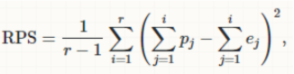

```r
unique(ratings[, list(bookmaker, avgavgRPS,rating)])
```

```
##       bookmaker avgavgRPS rating
##  1:      bet365 0.1898549      1
##  2:   BetVictor 0.1900245      2
##  3:    Pinnacle 0.1900599      3
##  4:      188BET 0.1901519      4
##  5:     Betsafe 0.1901847      5
##  6:       12BET 0.1901975      6
##  7:        bwin 0.1902196      7
##  8:   betathome 0.1902234      8
##  9:     Betclic 0.1903249      9
## 10:       10Bet 0.1903415     10
## 11:      SBOBET 0.1903598     11
## 12:      Unibet 0.1903638     12
## 13:     Betsson 0.1903886     13
## 14: WilliamHill 0.1904512     14
## 15:      Betway 0.1905295     15
```

### Adding Features

The assumption is that the bookmakers determine their odds based on many statistics and knowledge about the teams, players, weather etc. We want to beat the bookmakers at predicting the match outcomes. So, we added two features; the first one is the total of points the teams make during the season and the second one is the performances of the teams when they are playing at home and away.

For the first one we used the traditional point calculation where the points equal to the sum of 3 times the number of wins and number of ties.

Points = 3*wins + ties

We subtracted the Away team point from the Home team point and used the point difference as the feature.

For the second one, we calculated the home and away performances of every team in the last 5 games they played. The calculation is basically the ratio of number of games won in home/away over 5. For example, if a team has won 3 games in the last 5 games they played in their home, the home performance rating is 0.60.

We wanted to add a rating of bookmakers as a feature as well based on their historical performances but their performances were similar as mentioned above. All of the feature extraction is handled under one function called extract_features.openclose() and the codde is in the Appendix.

### Models

As a base model we used the penalized regression model that was given with the project. We compared the performances of the models we developed with this model. Initially we trained a k-nn model with cross validation but it performed poorly so we moved on to other models. You can find the code for the k-nn model in the Appendix.

#### SVM with Multiple Classes

First, we trained a multiple class Support Vector Machine with 10-fold cross calidation with 2 replications. To achieve this, we used the tunePareto() function in the package with the same name[5]. The tuning was done on 2 kernels; “gaussian” and “polynomial” and an interval of [0.01,2] for the cost parameter. The interval of the cost parameter is narrow becaunse when we tried with wider intervals the computation time was too long and the best combinations had cost parameters less than 2. We did the submissions with the best model the “svm” generated. Although this model generated fairly good results its runtime was too high so we decided to try out a new model. The function that performs the svm for our model can be found in the appendix. The kernel and the cost parameter chosen for the test data is as follows:

```r
pred_svm$bestcombinations
```

```
## [[1]]
## [[1]]$cost
## [1] 1.543339
##
## [[1]]$kernel
## [1] "radial"
```

#### Ordered Logistic Regression

As our final model we decided to implement an ordinal regression model with the polr() function. The details of the final model and the logic behind it are explained below. The code for the ordered logistic regression can be found in the Appendix.

polr() function fits a Proportional Odds Logistic Model and we use the default method in the function whis is “logistic”. The formula of the fitted model is as follows [1]:

logitP(Y<=k|x)=Ak-n

On the right side n represents a linear regression model with the coefficients and predictors and Ak is an intercept that changes depending on level k. Here k represents the levels of an ordered category [6]. In our case, we have 3 levels and k = 1 corresponds to “Home”. This function models the probability of being in category k or lower versus being in categories above it. In our example, P(Y<=2) means the probability of match result being “Home” or “Tie” versus being “Away”.

## Results

The following table illustrates the RPS values of three methods, namely support vector machines, penalized regression and ordinal regression, we used to perform our predictions and the RPS values of the bookmakers included in the model. As it can be seen, the final method we chose, “olr”, performs the best in terms of RPS values and all of the models developed outperform the bookmakers. (For the results here the test start date is 2018-12-29)

```r
meang
```

```
##        approach       rps
##  1:         olr 0.1783926
##  2:         svm 0.1986468
##  3:         glm 0.1957334
##  4:       10Bet 0.2600204
##  5:       12BET 0.2587616
##  6:      188BET 0.2591840
##  7:   BetVictor 0.2602725
##  8:     Betclic 0.2600654
##  9:     Betsafe 0.2604921
## 10:     Betsson 0.2608983
## 11:      Betway 0.2604509
## 12:    Pinnacle 0.2596841
## 13:      SBOBET 0.2578348
## 14:      Unibet 0.2623871
## 15: WilliamHill 0.2607328
## 16:      bet365 0.2616121
## 17:   betathome 0.2592605
## 18:        bwin 0.2610727
```

## Conclusions and Future Work

```r
coeff[sig == 1,]
```

```
##          Value  Std. Error    t value       pvalue sig
## 1: -0.01870854 0.004572861  -4.091211 4.291259e-05   1
## 2:  4.13907566 0.263654085  15.698887 1.539190e-55   1
## 3: -3.91639139 0.252345217 -15.519975 2.541510e-54   1
## 4: -0.99040737 0.345247022  -2.868692 4.121730e-03   1
## 5: -0.73514826 0.367908183  -1.998184 4.569671e-02   1
## 6:  0.32379429 0.137883823   2.348312 1.885870e-02   1
## 7: -0.86681892 0.329512568  -2.630610 8.523188e-03   1
## 8:  0.36788216 0.183169875   2.008421 4.459861e-02   1
## 9: -2.13044057 0.780114295  -2.730934 6.315514e-03   1
```

For future works, firstly, the goodness of fit of the model and the significance of the variables can be more closely observed and maybe a better model can be found. Secondly, we can improve the quality of the feature the home/away performance of teams in the last 5 games that we created by selecting the best number of last matches to be used for the performance calculation by checking its effect on RPS.

## References

[1] polr function in R https://www.rdocumentation.org/packages/MASS/versions/7.3-51.1/topics/polr

[2] Venables, W. N. & Ripley, B. D. (2002) Modern Applied Statistics with S. Fourth Edition. Springer, New York. ISBN 0-387-95457-0

[3] Goller, Daniel & Knaus, Michael & Lechner, Michael & Okasa, Gabriel. (2018). Predicting Match Outcomes in Football by an Ordered Forest Estimator.

[4] Buursma D., “Predicting sports events from past results towards effective betting on football matches”, Conference paper, presented at 14th Twente Student Conference on IT, Twente, Holland, 21 January 2011

[5] Christoph Mussel, Ludwig Lausser, Markus Maucher, Hans A. Kestler (2012). Multi-Objective Parameter Selection for Classifiers. Journal of Statistical Software, 46(5), 1-27. URL http://www.jstatsoft.org/v46/i05/.

[6] https://data.library.virginia.edu/fitting-and-interpreting-a-proportional-odds-model/

[7] https://CRAN.R-project.org/package=e1071

## Appendix

### Main

```r
require(data.table)
require(TunePareto)
require(glmnet)
require(MASS)

matches_data_path='/Users/silaaydin/Desktop/fall18/582/project/df9b1196-e3cf-4cc7-9159-f236fe738215_matches.rds'
odd_details_data_path='/Users/silaaydin/Desktop/fall18/582/project/df9b1196-e3cf-4cc7-9159-f236fe738215_odd_details.rds'
testStart=as.Date('2018-12-29')
trainStart=as.Date('2012-07-15')
rem_miss_threshold=0.01 #parameter for removing bookmaker odds with missing ratio greater than this threshold

source('data_preprocessing.r')
source('feature_extraction.r')
source('performance_metrics.r')
source('train_models.r')
source('train_svm.r')
source('ordered_log_reg.r')
source('bookmaker_RPS.r')
# read data
matches_raw=readRDS(matches_data_path)
odd_details_raw=readRDS(odd_details_data_path)

# preprocess matches
matches=matches_data_preprocessing(matches_raw)

# preprocess odd data
odd_details=details_data_preprocessing(odd_details_raw,matches)

# extract open and close odd type features from multiple bookmakers
ext_feat=extract_features.openclose(matches,odd_details,pMissThreshold=rem_miss_threshold,trainStart,testStart)
features = ext_feat$features
ratings = ext_feat$ratings
bookies = ext_feat$bookies
# divide data based on the provided dates
train_features=features[Match_Date>=trainStart & Match_Date<testStart]
test_features=features[Match_Date<= "2019-01-03" & Match_Date>=testStart]

predictions2=train_glmnet(train_features, test_features,not_included_feature_indices=c(1:9), alpha=1,nlambda=50, tune_lambda=TRUE,nofReplications=2,nFolds=10,trace=T)
pred_svm = train_svm(train_features[, -c(1:6,8,9)],test_features[, -c(1:9)])
pred_olr=train_orr(train_features, test_features)

coeff = coefficients(summary(pred_olr$model))
p <- pnorm(abs(coeff[, "t value"]), lower.tail = FALSE) * 2
coeff <- cbind(coeff, "pvalue" = p)
coeff = as.data.table(coeff)
coeff[pvalue <= 0.05, sig := 1]

k=matches[Match_Date>= testStart]
k.svm = k
g=k
k=merge(predictions2$predictions, k[,.(matchId, Home, Away, Result_Home, Result_Tie, Result_Away)], by = "matchId") # glmnet
k.svm=merge(pred_svm$predictions, k.svm[,.(matchId, Home, Away, Result_Home, Result_Tie, Result_Away)], by = "matchId")
g=merge(pred_olr$predictions, g[,.(matchId, Home, Away, Result_Home, Result_Tie, Result_Away)], by = "matchId")

rps.svm = RPS_matrix(k.svm[, 3:5],k.svm[, 8:10])
rps.glm = RPS_matrix(k[, 3:5],k[, 8:10])
rps.olr = RPS_matrix(g[, 3:5],g[, 8:10])
mean(rps.svm)
mean(rps.glm)
mean(rps.olr)

bookmakers = bookmaker_RPS(bookies, matches[Match_Date >= testStart & Match_Date<= "2019-01-03"], odd_details[Match_Date >= testStart & Match_Date<= "2019-01-03"])
approach = c("olr", "svm", "glm", bookmakers$bookmaker)
rps = c(mean(rps.olr),mean(rps.svm),mean(rps.glm), bookmakers$RPS)
meang = data.table(approach, rps)
```

### Data Preprocessing

```r
matches_data_preprocessing <- function(data){




  temp = copy(data)
  temp = unique(temp,by="matchId")
  setnames(temp,c("home","away","score","date"),c("Home","Away","Score","Match_Date"))
  temp[,Home:=tolower(Home)]
  temp[,Away:=tolower(Away)]
  temp[,Match_DateTime:=as.POSIXct(Match_Date,tz="UTC",origin = as.POSIXct("1970-01-01",tz="UTC"))]
  temp[,Match_Hour := format(strptime(Match_DateTime,"%Y-%m-%d %H:%M:%OS"),'%H')]
  temp[,Match_Hour := as.numeric(Match_Hour)]
  temp[,Match_Date := as.Date(Match_DateTime,format="%Y-%m-%d")]
  temp[Home=="manchester-utd",Home:="manchester-united"]
  temp[Away=="manchester-utd",Away:="manchester-united"]
  temp[Home=="manchester united",Home:="manchester-united"]
  temp[Away=="manchester united",Away:="manchester-united"]
  temp[Home=="stoke",Home:="stoke city"]
  temp[Away=="stoke",Away:="stoke city"]
  temp[Home=="crystal palace",Home:="crystal-palace"]
  temp[Away=="crystal palace",Away:="crystal-palace"]
  temp[Home=="newcastle utd",Home:="newcastle"]
  temp[Away=="newcastle utd",Away:="newcastle"]

  temp[,AWA_FLAG:=0]
  temp[(Score %like% "AWA."),`:=`(Score=gsub("AWA.","",Score),AWA_FLAG=1)]
  temp[,POSTP_FLAG:=0]
  temp[(Score == "POSTP."),`:=`(Score=gsub("POSTP.","",Score),POSTP_FLAG=1)]
  temp[,CAN_FLAG:=0]
  temp[(Score == "CAN."),`:=`(Score=gsub("CAN.","",Score),CAN_FLAG=1)]
  latestDateTimeofKnownScore = max(temp[Score!=""]$Match_DateTime)
  POSTP_toberemoved = temp[which(temp$POSTP_FLAG==1 & temp$Match_DateTime <= latestDateTimeofKnownScore)]$matchId
  if(length(POSTP_toberemoved)!=0){
    cat("Following postponed matches are REMOVED during data_preprocessing:\n")
    print(data[matchId%in%POSTP_toberemoved,])
    temp=temp[!matchId%in%POSTP_toberemoved,]
  }
  POSTP_tobekept = temp[which(temp$POSTP_FLAG==1 & temp$Match_DateTime > latestDateTimeofKnownScore)]$matchId
  if(length(POSTP_tobekept)!=0){
    cat("Following postponed matches are KEPT during data_preprocessing:\n")
    print(data[matchId%in%POSTP_tobekept,])
  }

  temp[,c("Home_Score","Away_Score") := lapply(tstrsplit(Score,":",fixed=T),as.integer)]
  temp[,`:=`(Match_Result = ifelse(Home_Score == Away_Score, "Tie" , ifelse(Home_Score > Away_Score, 'Home' , 'Away'))
             ,Total_Score = Home_Score + Away_Score)]
  temp[,`:=`(Result_Home = ifelse(Match_Result=="Home",1,0)
             ,Result_Tie = ifelse(Match_Result=="Tie",1,0)
             ,Result_Away = ifelse(Match_Result=="Away",1,0))]

  temp[,c('Score','Match_DateTime','AWA_FLAG','POSTP_FLAG','CAN_FLAG'):=NULL]
  gc()
  return(temp)
}

#' Data Preprocessing for Odd Details Data
#'
#' Makes preprocessing on raw odd details data so that it can be used by other functions.
#' only 1x2 bets are considered, if you are interested in other type of odds manipulate ''which_bets''
#' @param data A data.table containing raw odd details data
#' @param remove_bookmaker A character vector containing the bookmakers to be removed
#' @export
#' @examples

details_data_preprocessing <- function(data,matches,which_bets=c('1x2'),remove_bookmaker=c('BetfairExchange','PaddyPower'),removeOlderThan=30){
  # data manipulation for historical odd data
  details = copy(data)

  #remove duplicate entries
  details = unique(details)

  details = details[betType %in% which_bets]
  details[,totalhandicap:=NULL]

  details = merge(details,matches[,list(matchId,Match_Date)],by="matchId",all.x=T)
  setnames(details,"date","OddChangeDateTime")
  details[,OddChangeDateTime:=as.POSIXct(OddChangeDateTime,tz="UTC",origin = as.POSIXct("1970-01-01",tz="UTC"))]
  details = details[difftime(Match_Date,OddChangeDateTime, units = "days") <= removeOlderThan] #remove odds seen earlier than 10 days from the match date
  details[, odd := as.numeric(odd)]

  details[,bookmaker:=gsub(" |-","",bookmaker)]
  if(!is.null(remove_bookmaker)){
    details = details[!(bookmaker %in% remove_bookmaker)]
  }

  gc()
  return(details)
}
```

### Feature Extraction

```r
#' Feature Extraction

extract_features.openclose <- function(matches,odd_details,pMissThreshold=0.01,trainStart,testStart){

  details = copy(odd_details)
  matches = copy(matches)

# Team points by season ------------------------------------------------
  season_start = c("2010-08-14", "2011-08-13", "2012-08-18", "2013-08-17", "2014-08-16", "2015-08-08", "2016-08-13", "2017-08-11","2018-08-10")
  season_end = c("2011-05-22", "2012-05-13", "2013-05-19", "2014-05-11", "2015-05-24", "2016-05-17", "2017-05-21", "2018-05-13",as.character(testStart))
  team_stats=data.table()
  t=1
  for(k in season_start){
    j=season_end[t]
    teams = unique(matches[Match_Date>=k & Match_Date<=j, Home])
    d=matches[Match_Date>=k & Match_Date<=j]
    for(i in teams){
      totalgames = nrow(d[(Home%in%i | Away%in%i)])
      ties = nrow(d[(Home%in%i | Away%in%i) & Result_Tie == 1])
      wins = nrow(d[Home%in%i  & Result_Home == 1])
      wins = wins + nrow(d[Away%in%i  & Result_Away == 1])
      losts = totalgames - wins - ties
      team_stats=rbind(team_stats, data.table(season=t, team=i,wins=wins,ties=ties,losts=losts))
    }
    t=t+1
  }
  team_stats[,point:=(3*wins+1*ties), by=.(team)]
  t=1
  for(k in season_start){
    j=season_end[t]
    teams = unique(matches[Match_Date>=k & Match_Date<=j, Home])
  for(i in teams){
    pt=team_stats[team == i & season == t, point]
    matches[Home%in%i & Match_Date>=k, Home_pt:=pt]
    matches[Away%in%i & Match_Date>=k, Away_pt:=pt]
  }
    t=t+1
    }
  matches[, pt_dif:=Home_pt-Away_pt]

# Last 5 game performances ------------------------------------------------

  teams = unique(matches[,Home])
  t= teams[1]
  result_home = list()
  iter=1
  for(t in teams){
    v = matches[Home == t]
    v = v[order(Match_Date)]
    v[Match_Result != "NA", date_id := 1:.N]
    a = v[date_id == 1, Result_Home]
    v[date_id ==1, home_perf := a]
    b = v[date_id == 2, Result_Home]
    v[date_id ==2, home_perf := (a+b)/2]
    c = v[date_id == 3, Result_Home]
    v[date_id == 3, home_perf := (a+b+c)/3]
    d = v[date_id == 4, Result_Home]
    v[date_id ==4, home_perf := (a+b+c+d)/4]
    x=nrow(v[date_id != "NA"])

    for(i in v$date_id[5:x]){
      perf = v[date_id <= i & date_id >= i-4, mean(Result_Home)]
      v[date_id == i, home_perf := perf]
    }
    perf = v$home_perf[x]
    v[is.na(date_id) == T, home_perf := perf]
    result_mid = rbindlist(lapply(c(1:nrow(v)), function(x) {data.table(team = t, Match_Date = v$Match_Date[x], home_perf = v$home_perf[x])}))
    result_home[[iter]] = result_mid
    iter = iter+1
  }
  result_home = rbindlist(result_home)
  setnames(result_home, "team", "Home")

  teams = unique(matches[,Away])
  result_away = list()
  iter=1
  for(t in teams){
    v = matches[Away == t]
    v = v[order(Match_Date)]
    v[Match_Result != "NA", date_id := 1:.N]
    a = v[date_id == 1, Result_Away]
    v[date_id ==1, away_perf := a]
    b = v[date_id == 2, Result_Away]
    v[date_id ==2, away_perf := (a+b)/2]
    c = v[date_id == 3, Result_Away]
    v[date_id == 3, away_perf := (a+b+c)/3]
    d = v[date_id == 4, Result_Away]
    v[date_id ==4, away_perf := (a+b+c+d)/4]
    x=nrow(v[date_id != "NA"])

    for(i in v$date_id[5:x]){
      perf = v[date_id <= i & date_id >= i-4, mean(Result_Away)]
      v[date_id == i, away_perf := perf]
    }
    perf = v$away_perf[x]
    v[is.na(date_id) == T, away_perf := perf]
    result_mid = rbindlist(lapply(c(1:nrow(v)), function(x) {data.table(team = t, Match_Date = v$Match_Date[x], away_perf = v$away_perf[x])}))
    result_away[[iter]] = result_mid
    iter = iter+1
  }
  result_away = rbindlist(result_away)
  setnames(result_away, "team", "Away")
  matches = merge(matches, result_away, by = c("Match_Date","Away"))
  matches = merge(matches, result_home, by = c("Match_Date","Home"))

# details -----------------------------------------------------------------

  details=details[order(OddChangeDateTime)]
  feature_odd_details=details[,list(Odd_Open=odd[1],Odd_Close=odd[.N]),list(matchId,betType,oddtype,bookmaker)]

  feature_odd_details = merge(matches[,list(matchId,Match_Date)], feature_odd_details,by="matchId")

  #HANDLE MISSINGS
  details_temp = dcast(feature_odd_details, matchId+betType ~ paste0("Odd_Close_",bookmaker)+oddtype, value.var = c("Odd_Close"))
  details_melt = melt(details_temp, id.vars = c("matchId","betType"), measure.vars = names(details_temp)[names(details_temp) %like% "Odd_Close"], value.name = "odd")
  details_melt[,c("OpenClose","bookmaker","oddtype"):=tstrsplit(variable,split="_",keep=c(2:4))]
  details_melt[,variable:=NULL]
  details_melt = merge(matches[,list(matchId,Match_Date)], details_melt,by="matchId",all=T)

  bookieMissingness = details_melt[Match_Date >= trainStart,list(.N,percMiss=sum(is.na(odd))/.N),by=list(bookmaker,betType)]
  bookiesToKeep = unique(bookieMissingness[percMiss <= pMissThreshold]$bookmaker)
  cat("Number of bookmakers with proportion of missings below",pMissThreshold,"since",as.character(trainStart),":",length(bookiesToKeep),"\n")

  nonmissingBookmakers_sinceTestStart = unique(details_melt[Match_Date >= testStart, list(.N,NA_SUM=sum(is.na(odd))),by=list(bookmaker,betType)][NA_SUM==0]$bookmaker)
  bookiesToKeep = intersect(bookiesToKeep,nonmissingBookmakers_sinceTestStart)
  cat("Number of bookmakers with no missings since testStart", as.character(testStart), ":", length(bookiesToKeep), "\n")

  details = dcast(feature_odd_details,matchId~oddtype+bookmaker,value.var = c("Odd_Open","Odd_Close"))
  columnsToKeep = grep(paste(bookiesToKeep,collapse="|"),names(details),value=T)
  details = details[,c('matchId',columnsToKeep),with=F]
  #HANDLE MISSINGS END


  details = merge(matches[,-c('Home_Score','Away_Score','Total_Score','Result_Home','Result_Tie','Result_Away','type'),with=F],
                  details,by="matchId",all=T)

  # details 1 is for rating the bookmakers based on their final odds

  details1 = dcast(feature_odd_details,matchId~paste0("tomelt_",oddtype)+bookmaker,value.var = c("Odd_Close"))

  columnsToKeep = grep(paste(bookiesToKeep,collapse="|"),names(details1),value=T)
  details1 = details1[,c('matchId',columnsToKeep),with=F]
  #HANDLE MISSINGS END

  details1 = merge(matches[,-c('Home','Away','Home_Score','Away_Score','Total_Score','Match_Result','type'),with=F],
                  details1,by="matchId",all=T)

  details2 = melt(details1, id.vars = c("matchId", "Match_Date", "Match_Hour","Result_Home", "Result_Away", "Result_Tie" ), measure.vars = names(details1)[names(details1) %like% "tomelt_"], value.name = "odd")
  details2[,c("oddtype","bookmaker"):=tstrsplit(variable,split="_",keep=c(2:3))]
  details2[, variable:=NULL]
  details3 = dcast(details2,matchId+bookmaker+Match_Date+Match_Hour+Result_Home+Result_Away+Result_Tie~oddtype,value.var = c("odd"))
  details3[,prob_home:= 1/odd1,]
  details3[,prob_away:= 1/odd2,]
  details3[,prob_tie:= 1/oddX,]
  details3[,prob_tot:= prob_away+prob_home+prob_tie,]
  details3[,prob_home:=prob_home/prob_tot]
  details3[,prob_away:=prob_away/prob_tot]
  details3[,prob_tie:=prob_tie/prob_tot]
  details3[,prob_tot:= NULL,]
  details3[, RPS:= RPS_matrix(details3[,11:13],details3[,5:7])]
  details3=details3[Match_Date>= "2016-11-01"]
  details3[, cuts:=cut(details3$Match_Date, breaks = "1 month")]
  details3[, avgRPS := mean(RPS, na.omit = TRUE), by=.(bookmaker, cuts)]
  ratings=unique(details3[,c("bookmaker", "avgRPS", "cuts")])
  ratings[,avgavgRPS:=mean(avgRPS, na.omit=TRUE), by=.(bookmaker)]
  ratings=ratings[order(avgavgRPS)]
  ratings$rating = factor(ratings$avgavgRPS, levels = unique(ratings$avgavgRPS), labels = c(1: length(unique(ratings$bookmaker))))

  return(list(features = details, ratings = ratings, bookies = bookiesToKeep))
}
```

### RPS

```r
RPS_single<- function(probs,outcomes){
  probs = cumsum(probs)
  outcomes = cumsum(outcomes)
  RPS = sum((probs-outcomes )^2) / (length(probs)-1)
  return(RPS)
}

RPS_matrix<- function(probs,outcomes){
  probs=as.matrix(probs)
  outcomes=as.matrix(outcomes)
  probs=t(apply(t(probs), 2, cumsum))
  outcomes=t(apply(t(outcomes), 2, cumsum))
  RPS = apply((probs-outcomes)^2,1,sum) / (ncol(probs)-1)
  return(RPS)
}
```

### Logistic Regression

```r
train_glmnet <- function(train_features, test_features,not_included_feature_indices=c(1:5), alpha=1,nlambda=50, tune_lambda=TRUE,nofReplications=2,nFolds=10,trace=T){

  set.seed(1)

  # glmnet works with complete data
  glm_features=train_features[complete.cases(train_features)]
  train_class=glm_features$Match_Result
  glm_train_data=glm_features[,-not_included_feature_indices,with=F]
  glm_test_data=test_features[,-not_included_feature_indices,with=F]
  if(tune_lambda){
    # to set lambda parameter, cross-validation will be performed and lambda is selected based on RPS performance

    cvindices=generateCVRuns(train_class,nofReplications,nFolds,stratified=TRUE)

    # first get lambda sequence for all data
    glmnet_alldata = glmnet(as.matrix(glm_train_data), as.factor(train_class), family="multinomial", alpha = alpha, nlambda=nlambda)
    lambda_sequence = glmnet_alldata$lambda

    cvresult=vector('list',nofReplications*nFolds)
    iter=1
    for(i in 1:nofReplications) {
      thisReplication=cvindices[[i]]
      for(j in 1:nFolds){
        if(trace){
          cat(sprintf('Iteration %d: Fold %d of Replication %d\n',iter,j,i))
        }
        testindices=thisReplication[[j]]

        cvtrain=glm_train_data[-testindices]
        cvtrainclass=train_class[-testindices]
        cvtest=glm_train_data[testindices]
        cvtestclass=train_class[testindices]

        inner_cv_glmnet_fit = glmnet(as.matrix(cvtrain),as.factor(cvtrainclass),family="multinomial", alpha = alpha,lambda=lambda_sequence)
        valid_pred = predict(inner_cv_glmnet_fit, as.matrix(cvtest), s = lambda_sequence, type = "response")

        #check order of predictions
        order_of_class=attr(valid_pred,'dimnames')[[2]]
        new_order=c(which(order_of_class=='Home'),which(order_of_class=='Tie'),which(order_of_class=='Away'))
        foldresult=rbindlist(lapply(c(1:length(lambda_sequence)),function(x) { data.table(repl=i,fold=j,lambda=lambda_sequence[x],valid_pred[,new_order,x],result=cvtestclass)}))
        cvresult[[iter]]=foldresult
        iter=iter+1


      }
    }


    cvresult=rbindlist(cvresult)

    # creating actual targets for rps calculations
    cvresult[,pred_id:=1:.N]
    outcome_for_rps=data.table::dcast(cvresult,pred_id~result,value.var='pred_id')
    outcome_for_rps[,pred_id:=NULL]
    outcome_for_rps[is.na(outcome_for_rps)]=0
    outcome_for_rps[outcome_for_rps>0]=1
    setcolorder(outcome_for_rps,c('Home','Tie','Away'))

    # calculate RPS
    overall_results=data.table(cvresult[,list(repl,fold,lambda)],RPS=RPS_matrix(cvresult[,list(Home,Tie,Away)],outcome_for_rps))

    # summarize performance for each lambda
    overall_results_summary=overall_results[,list(RPS=mean(RPS)),list(repl,fold,lambda)]

    # find best lambdas as in glmnet based on RPS
    overall_results_summary=overall_results_summary[,list(meanRPS=mean(RPS),sdRPS=sd(RPS)),list(lambda)]
    overall_results_summary[,RPS_mean_lb := meanRPS - sdRPS]
    overall_results_summary[,RPS_mean_ub := meanRPS + sdRPS]

    cv_lambda_min=overall_results_summary[which.min(meanRPS)]$lambda

    semin=overall_results_summary[lambda==cv_lambda_min]$RPS_mean_ub
    cv_lambda.1se=max(overall_results_summary[meanRPS<semin]$lambda)

    cvResultsSummary = list(lambda.min =cv_lambda_min, lambda.1se = cv_lambda.1se,
                            meanRPS_min=overall_results_summary[lambda==cv_lambda_min]$meanRPS,
                            meanRPS_1se=overall_results_summary[lambda==cv_lambda.1se]$meanRPS)

  }

  # fit final glmnet model with the lambda with minimum error
  final_glmnet_fit = glmnet(as.matrix(glm_train_data),as.factor(train_class),family="multinomial", alpha = alpha,lambda=cvResultsSummary$lambda.min)
  # obtain predictions
  predicted_probabilities=predict(final_glmnet_fit, as.matrix(glm_test_data), type = "response")

  #check order of predictions
  order_of_class=attr(predicted_probabilities,'dimnames')[[2]]
  new_order=c(which(order_of_class=='Home'),which(order_of_class=='Tie'),which(order_of_class=='Away'))

  final_result=data.table(test_features[,list(matchId,Match_Result)],predicted_probabilities[,new_order,1])

  return(list(predictions=final_result,cv_stats=cvResultsSummary))
}
```

### Support Vector Machine

```r
train_svm = function(traindata, testdata) {
  start_time = Sys.time()
  traindata$Match_Result = as.factor(traindata$Match_Result)
  traindata=traindata[complete.cases(traindata)]

  svm_fit = tunePareto(data = traindata[, -"Match_Result"],
                       labels = traindata[, Match_Result],
                       classifier = tunePareto.svm(),
                       cost = as.interval(0.01,2),
                       kernel = c("polynomial","radial"),
                       sampleType="latin",
                       numCombinations=20,
                       objectiveFunctions = list(cvError(10, 2)))
  x = svm_fit$bestCombinations
  x = rbindlist(x)
  cost = x[1,]$cost
  kernel = x[1,]$kernel
  svm_fin = svm(traindata[, Match_Result]~., data = traindata[, -"Match_Result"], kernel = kernel, cost = cost, probability = T)
  pred = predict(svm_fin, as.matrix(testdata), probability = T)
  order_of_class=levels(pred)
  new_order=c(which(order_of_class=='Home'),which(order_of_class=='Tie'),which(order_of_class=='Away'))
  res = as.data.frame(attr(pred, "probabilities"))
  res[, new_order]
  final_result=data.table(test_features[,list(matchId,Match_Result)],res[,new_order,])
  end_time = Sys.time()
  t = end_time - start_time
  return(list(predictions = final_result, model = svm_fin, cost = x[1,]$cost, kernel = x[1,]$kernel, bestcombinations = svm_fit$bestCombinations, runtime = t))
}
```

### Ordered Logistic Regression

```r
train_orr<-function(traindata, testdata, nofReplications=2, nFolds=10){
  set.seed(18237)
  k=1
  traindata=train_features
  testdata=test_features
  traindata$Match_Result = as.factor(traindata$Match_Result)
  traindata=traindata[complete.cases(traindata)]
  trainclass=traindata$Match_Result
  trainclass=factor(trainclass, levels = c("Home", "Tie", "Away"))
  traindata=traindata[,-c(1:9)]
  cvindices=generateCVRuns(trainclass,nofReplications,nFolds,stratified=TRUE)
  olr_result=data.table()
  olr_models<-list()
  for(i in 1:nofReplications){
    thisReplication=cvindices[[i]]
      for(j in 1:nFolds){
        testindices=thisReplication[[j]]
        olrtrain=traindata[-testindices]
        olrtrainclass=trainclass[-testindices]
        olrtest=traindata[testindices]
        olrtestclass=trainclass[testindices]
        olr_fit=polr(olrtrainclass~.,olrtrain,Hess=TRUE, model=TRUE)
        olr_models[[k]]=olr_fit
        olr_predicted=predict(olr_fit, olrtest, type="p")
        olr_result=rbind(olr_result,data.table(rep=i,fold=j,olr_predicted, result=olrtestclass))
        k=k+1
      }
  }
  olr_result[,pred_id:=1:.N]
  outcome_for_rps=data.table::dcast(olr_result,pred_id~result,value.var='pred_id')
  outcome_for_rps[,pred_id:=NULL]
  outcome_for_rps[is.na(outcome_for_rps)]=0
  outcome_for_rps[outcome_for_rps>0]=1
  #setcolorder(outcome_for_rps,c('Home','Tie','Away'))
  overall_results=data.table(olr_result[,list(rep,fold)],RPS=RPS_matrix(olr_result[,list(Home,Tie,Away)],outcome_for_rps))
  overall_results[rep==1&fold==2,sum(RPS)]
  overall_results[rep==1&fold==1,sum(RPS)]
  summary_result=overall_results[,list(RPS=mean(RPS)),list(rep,fold)]
  final_fit=olr_models[[which.min(summary_result$RPS)]]

  final_pred=predict(final_fit,testdata[,-c(1:9)], type = "p")
  final_res=data.table(testdata[, list(matchId, Match_Result)], final_pred)
  return(list(predictions=final_res, model = final_fit))
  }
```

### Bookmaker RPS

```r
bookmaker_RPS = function(bookies, ma, odd){
  bookmakers = bookies
  odd=odd[order(OddChangeDateTime)]
  odd=odd[,list(Odd_Close=odd[.N]),list(matchId,betType,oddtype,bookmaker)]
  r = dcast(odd,matchId+bookmaker~oddtype,value.var = c("Odd_Close"))
  r[,prob_home:= 1/odd1,]
  r[,prob_away:= 1/odd2,]
  r[,prob_tie:= 1/oddX,]
  r[,prob_tot:= prob_away+prob_home+prob_tie,]
  r[,prob_home:=prob_home/prob_tot]
  r[,prob_away:=prob_away/prob_tot]
  r[,prob_tie:=prob_tie/prob_tot]
  v = merge(r, ma[,list(Result_Home, Result_Tie, Result_Away, matchId)], all.x = T, by = "matchId")
  z=data.table()
  for(i in bookmakers){
    f = v[bookmaker == i, ]
    z = rbind(z,data.table(bookmaker = i, RPS = mean(RPS_matrix(f[,6:8], f[, 10:12]))))
  }
  return(z)
}
```

### KNN

```r
train_knn<-function(train_features, test_features,not_included_feature_indices=c(1:5), alpha=1,nlambda=50, tune_lambda=TRUE,nofReplications=2,nFolds=10,trace=T, kLevel=c(3:10)){
  set.seed(1)

  # glmnet works with complete data
  knn_features=train_features[complete.cases(train_features)]
  knn_train_class=knn_features$Match_Result
  knn_train_class = factor(knn_train_class, levels = c("Home", "Tie", "Away"), labels = c(1:3))
  knn_train_data=knn_features[,-not_included_feature_indices,with=F]
  knn_test_data=test_features[,-not_included_feature_indices,with=F]
  if(tune_lambda){
    # to set lambda parameter, cross-validation will be performed and lambda is selected based on RPS performance

    cvindices=generateCVRuns(train_class,nofReplications,nFolds,stratified=TRUE)
    cvresult2=data.table()
    iter=1
    for(i in 1:nofReplications) {
      thisReplication=cvindices[[i]]
      for(j in 1:nFolds){
        for(k in kLevel){
          testindices=thisReplication[[j]]
          cvtrain=knn_train_data[-testindices]
          cvtrainclass=knn_train_class[-testindices]
          cvtest=knn_train_data[testindices]
          cvtestclass=train_class[testindices]
          cv_knn_fit=kknn(cvtrainclass~.,as.data.frame(cvtrain),as.data.frame(cvtest),k=k,distance=2, kernel="optimal")
          cvresult2=rbind(cvresult2, data.table(Replication=i,Fold=j, Klev=k,TestId=testindices, ProbHome=as.numeric(cv_knn_fit$prob[,1]),ProbTie=cv_knn_fit$prob[,2],ProbAway=cv_knn_fit$prob[,3],Result=train_class[testindices]))
        }}}

    cvresult2[,pred_id:=1:.N]
    outcome_for_rps_knn=data.table::dcast(cvresult2,pred_id~Result,value.var='pred_id')
    outcome_for_rps_knn[,pred_id:=NULL]
    outcome_for_rps_knn[is.na(outcome_for_rps_knn)]=0
    outcome_for_rps_knn[outcome_for_rps_knn>0]=1
    setcolorder(outcome_for_rps,c('Home','Tie','Away'))

    #calculate RPS
    overall_results_knn=data.table(cvresult2[,list(Replication,Fold,Klev)],RPS=RPS_matrix(cvresult2[,list(ProbHome,ProbTie,ProbAway)],outcome_for_rps_knn))

    # summarize performance for each k
    overall_results_summary_knn=overall_results_knn[,list(RPS=mean(RPS)),list(Klev)]


    cv_K_min=overall_results_summary_knn[which.min(RPS)]$Klev

  }
  final_knn_fit=kknn(knn_train_class~., as.data.frame(knn_train_data),as.data.frame(knn_test_data),k=cv_K_min,distance = 2, kernel = "optimal")
  final_result_knn=data.table(test_features[,list(matchId,Match_Result)],final_knn_fit$prob)
  return(list(predictions=final_result_knn, kLevel=cv_K_min, RPS=overall_results_summary_knn[which.min(RPS)]))
}
```